# Arbolibro: A Community Book-Share Project

# Our Mission

Arbolibro’s mission is for children and adults to take books home, read, and enjoy them for free.

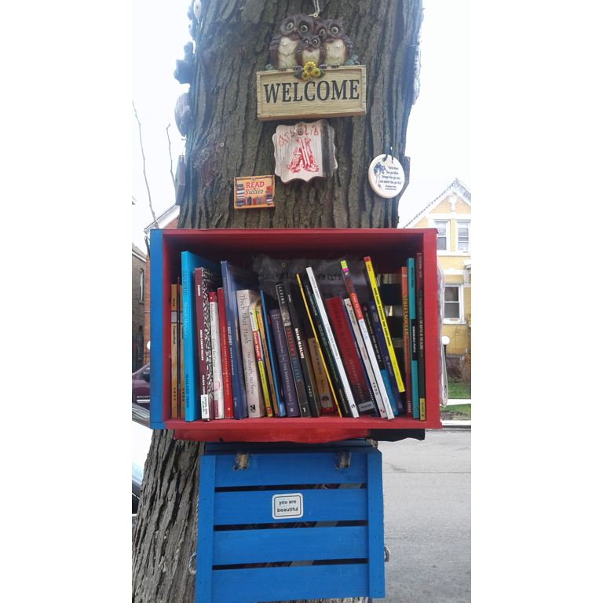

# Our History

Arbolibro was born in August of 2016 by me, thanks to my kids and their love of reading.

[figure not shown]

Working and going to school full-time only allowed once a week trips to the local library. One day, I thought of the idea of starting a book-share project in my Little Village neighborhood in Chicago, IL. Now our kids can grab a book right down the street instead of waiting for me to take them to the library.

# Our Motivation

Families from low-income communities struggle with literacy for several reasons. Limited education, a need to work multiple jobs, and little knowledge or access to resources. Arbolibro empowers and educates the community offering free literature for all ages.

In the United States, book-sharing has been promoted as a valuable activity that parents and children can do together to enhance literacy skills. Reading with your child has many positive benefits and is the key to your child’s academic future.